# Optimal Treatment Analysis

## Outcome Variable

**Outcome Variable:** whz

## Predictor Variables

**Intervention Variable:** single

**Adjustment Set:**

- arm
- W_mage
- W_fage
- meducyrs
- feducyrs
- W_mhtcm
- W_mwtkg
- W_mbmi
- delta_W_mage
- delta_W_fage
- delta_meducyrs
- delta_feducyrs
- delta_W_mhtcm
- delta_W_mwtkg
- delta_W_mbmi

## Stratifying Variables

The analysis was stratified on these variable(s):

- agecat
- studyid
- country

## Data Summary

| agecat | studyid | country | single | n_cell | n |
| --- | --- | --- | --- | --- | --- |
| Birth | ki0047075b-MAL-ED | BANGLADESH | 0 | 241 | 241 |
| Birth | ki0047075b-MAL-ED | BANGLADESH | 1 | 0 | 241 |
| Birth | ki0047075b-MAL-ED | BRAZIL | 0 | 159 | 183 |
| Birth | ki0047075b-MAL-ED | BRAZIL | 1 | 24 | 183 |
| Birth | ki0047075b-MAL-ED | INDIA | 0 | 202 | 202 |
| Birth | ki0047075b-MAL-ED | INDIA | 1 | 0 | 202 |
| Birth | ki0047075b-MAL-ED | NEPAL | 0 | 168 | 168 |
| Birth | ki0047075b-MAL-ED | NEPAL | 1 | 0 | 168 |
| Birth | ki0047075b-MAL-ED | PERU | 0 | 247 | 279 |
| Birth | ki0047075b-MAL-ED | PERU | 1 | 32 | 279 |
| Birth | ki0047075b-MAL-ED | SOUTH AFRICA | 0 | 145 | 258 |
| Birth | ki0047075b-MAL-ED | SOUTH AFRICA | 1 | 113 | 258 |
| Birth | ki0047075b-MAL-ED | TANZANIA, UNITED REPUBLIC OF | 0 | 112 | 118 |
| Birth | ki0047075b-MAL-ED | TANZANIA, UNITED REPUBLIC OF | 1 | 6 | 118 |
| Birth | ki1119695-PROBIT | BELARUS | 0 | 13286 | 13824 |
| Birth | ki1119695-PROBIT | BELARUS | 1 | 538 | 13824 |
| Birth | ki1126311-ZVITAMBO | ZIMBABWE | 0 | 12064 | 12863 |
| Birth | ki1126311-ZVITAMBO | ZIMBABWE | 1 | 799 | 12863 |
| Birth | ki1135781-COHORTS | GUATEMALA | 0 | 654 | 691 |
| Birth | ki1135781-COHORTS | GUATEMALA | 1 | 37 | 691 |
| Birth | ki1135781-COHORTS | INDIA | 0 | 4456 | 4463 |
| Birth | ki1135781-COHORTS | INDIA | 1 | 7 | 4463 |
| Birth | ki1135781-COHORTS | PHILIPPINES | 0 | 2789 | 2860 |
| Birth | ki1135781-COHORTS | PHILIPPINES | 1 | 71 | 2860 |
| 6 months | ki0047075b-MAL-ED | BANGLADESH | 0 | 241 | 241 |
| 6 months | ki0047075b-MAL-ED | BANGLADESH | 1 | 0 | 241 |
| 6 months | ki0047075b-MAL-ED | BRAZIL | 0 | 179 | 209 |
| 6 months | ki0047075b-MAL-ED | BRAZIL | 1 | 30 | 209 |
| 6 months | ki0047075b-MAL-ED | INDIA | 0 | 234 | 234 |
| 6 months | ki0047075b-MAL-ED | INDIA | 1 | 0 | 234 |
| 6 months | ki0047075b-MAL-ED | NEPAL | 0 | 236 | 236 |
| 6 months | ki0047075b-MAL-ED | NEPAL | 1 | 0 | 236 |
| 6 months | ki0047075b-MAL-ED | PERU | 0 | 240 | 273 |
| 6 months | ki0047075b-MAL-ED | PERU | 1 | 33 | 273 |
| 6 months | ki0047075b-MAL-ED | SOUTH AFRICA | 0 | 140 | 254 |
| 6 months | ki0047075b-MAL-ED | SOUTH AFRICA | 1 | 114 | 254 |
| 6 months | ki0047075b-MAL-ED | TANZANIA, UNITED REPUBLIC OF | 0 | 239 | 247 |
| 6 months | ki0047075b-MAL-ED | TANZANIA, UNITED REPUBLIC OF | 1 | 8 | 247 |
| 6 months | ki1066203-TanzaniaChild2 | TANZANIA, UNITED REPUBLIC OF | 0 | 1834 | 2012 |
| 6 months | ki1066203-TanzaniaChild2 | TANZANIA, UNITED REPUBLIC OF | 1 | 178 | 2012 |
| 6 months | ki1112895-Guatemala BSC | GUATEMALA | 0 | 248 | 277 |
| 6 months | ki1112895-Guatemala BSC | GUATEMALA | 1 | 29 | 277 |
| 6 months | ki1119695-PROBIT | BELARUS | 0 | 15114 | 15757 |
| 6 months | ki1119695-PROBIT | BELARUS | 1 | 643 | 15757 |
| 6 months | ki1126311-ZVITAMBO | ZIMBABWE | 0 | 7746 | 8234 |
| 6 months | ki1126311-ZVITAMBO | ZIMBABWE | 1 | 488 | 8234 |
| 6 months | ki1135781-COHORTS | GUATEMALA | 0 | 827 | 894 |
| 6 months | ki1135781-COHORTS | GUATEMALA | 1 | 67 | 894 |
| 6 months | ki1135781-COHORTS | INDIA | 0 | 4955 | 4964 |
| 6 months | ki1135781-COHORTS | INDIA | 1 | 9 | 4964 |
| 6 months | ki1135781-COHORTS | PHILIPPINES | 0 | 2606 | 2674 |
| 6 months | ki1135781-COHORTS | PHILIPPINES | 1 | 68 | 2674 |
| 24 months | ki0047075b-MAL-ED | BANGLADESH | 0 | 212 | 212 |
| 24 months | ki0047075b-MAL-ED | BANGLADESH | 1 | 0 | 212 |
| 24 months | ki0047075b-MAL-ED | BRAZIL | 0 | 148 | 169 |
| 24 months | ki0047075b-MAL-ED | BRAZIL | 1 | 21 | 169 |
| 24 months | ki0047075b-MAL-ED | INDIA | 0 | 225 | 225 |
| 24 months | ki0047075b-MAL-ED | INDIA | 1 | 0 | 225 |
| 24 months | ki0047075b-MAL-ED | NEPAL | 0 | 228 | 228 |
| 24 months | ki0047075b-MAL-ED | NEPAL | 1 | 0 | 228 |
| 24 months | ki0047075b-MAL-ED | PERU | 0 | 176 | 201 |
| 24 months | ki0047075b-MAL-ED | PERU | 1 | 25 | 201 |
| 24 months | ki0047075b-MAL-ED | SOUTH AFRICA | 0 | 131 | 238 |
| 24 months | ki0047075b-MAL-ED | SOUTH AFRICA | 1 | 107 | 238 |
| 24 months | ki0047075b-MAL-ED | TANZANIA, UNITED REPUBLIC OF | 0 | 208 | 214 |
| 24 months | ki0047075b-MAL-ED | TANZANIA, UNITED REPUBLIC OF | 1 | 6 | 214 |
| 24 months | ki1066203-TanzaniaChild2 | TANZANIA, UNITED REPUBLIC OF | 0 | 6 | 6 |
| 24 months | ki1066203-TanzaniaChild2 | TANZANIA, UNITED REPUBLIC OF | 1 | 0 | 6 |
| 24 months | ki1119695-PROBIT | BELARUS | 0 | 3829 | 3971 |
| 24 months | ki1119695-PROBIT | BELARUS | 1 | 142 | 3971 |
| 24 months | ki1126311-ZVITAMBO | ZIMBABWE | 0 | 379 | 422 |
| 24 months | ki1126311-ZVITAMBO | ZIMBABWE | 1 | 43 | 422 |
| 24 months | ki1135781-COHORTS | GUATEMALA | 0 | 932 | 1021 |
| 24 months | ki1135781-COHORTS | GUATEMALA | 1 | 89 | 1021 |
| 24 months | ki1135781-COHORTS | INDIA | 0 | 3717 | 3726 |
| 24 months | ki1135781-COHORTS | INDIA | 1 | 9 | 3726 |
| 24 months | ki1135781-COHORTS | PHILIPPINES | 0 | 2361 | 2420 |
| 24 months | ki1135781-COHORTS | PHILIPPINES | 1 | 59 | 2420 |

The following strata were considered:

- agecat: 24 months, studyid: ki0047075b-MAL-ED, country: BANGLADESH
- agecat: 24 months, studyid: ki0047075b-MAL-ED, country: BRAZIL
- agecat: 24 months, studyid: ki0047075b-MAL-ED, country: INDIA
- agecat: 24 months, studyid: ki0047075b-MAL-ED, country: NEPAL
- agecat: 24 months, studyid: ki0047075b-MAL-ED, country: PERU
- agecat: 24 months, studyid: ki0047075b-MAL-ED, country: SOUTH AFRICA
- agecat: 24 months, studyid: ki0047075b-MAL-ED, country: TANZANIA, UNITED REPUBLIC OF
- agecat: 24 months, studyid: ki1066203-TanzaniaChild2, country: TANZANIA, UNITED REPUBLIC OF
- agecat: 24 months, studyid: ki1119695-PROBIT, country: BELARUS
- agecat: 24 months, studyid: ki1126311-ZVITAMBO, country: ZIMBABWE
- agecat: 24 months, studyid: ki1135781-COHORTS, country: GUATEMALA
- agecat: 24 months, studyid: ki1135781-COHORTS, country: INDIA
- agecat: 24 months, studyid: ki1135781-COHORTS, country: PHILIPPINES
- agecat: 6 months, studyid: ki0047075b-MAL-ED, country: BANGLADESH
- agecat: 6 months, studyid: ki0047075b-MAL-ED, country: BRAZIL
- agecat: 6 months, studyid: ki0047075b-MAL-ED, country: INDIA
- agecat: 6 months, studyid: ki0047075b-MAL-ED, country: NEPAL
- agecat: 6 months, studyid: ki0047075b-MAL-ED, country: PERU
- agecat: 6 months, studyid: ki0047075b-MAL-ED, country: SOUTH AFRICA
- agecat: 6 months, studyid: ki0047075b-MAL-ED, country: TANZANIA, UNITED REPUBLIC OF
- agecat: 6 months, studyid: ki1066203-TanzaniaChild2, country: TANZANIA, UNITED REPUBLIC OF
- agecat: 6 months, studyid: ki1112895-Guatemala BSC, country: GUATEMALA
- agecat: 6 months, studyid: ki1119695-PROBIT, country: BELARUS
- agecat: 6 months, studyid: ki1126311-ZVITAMBO, country: ZIMBABWE
- agecat: 6 months, studyid: ki1135781-COHORTS, country: GUATEMALA
- agecat: 6 months, studyid: ki1135781-COHORTS, country: INDIA
- agecat: 6 months, studyid: ki1135781-COHORTS, country: PHILIPPINES
- agecat: Birth, studyid: ki0047075b-MAL-ED, country: BANGLADESH
- agecat: Birth, studyid: ki0047075b-MAL-ED, country: BRAZIL
- agecat: Birth, studyid: ki0047075b-MAL-ED, country: INDIA
- agecat: Birth, studyid: ki0047075b-MAL-ED, country: NEPAL
- agecat: Birth, studyid: ki0047075b-MAL-ED, country: PERU
- agecat: Birth, studyid: ki0047075b-MAL-ED, country: SOUTH AFRICA
- agecat: Birth, studyid: ki0047075b-MAL-ED, country: TANZANIA, UNITED REPUBLIC OF
- agecat: Birth, studyid: ki1119695-PROBIT, country: BELARUS
- agecat: Birth, studyid: ki1126311-ZVITAMBO, country: ZIMBABWE
- agecat: Birth, studyid: ki1135781-COHORTS, country: GUATEMALA
- agecat: Birth, studyid: ki1135781-COHORTS, country: INDIA
- agecat: Birth, studyid: ki1135781-COHORTS, country: PHILIPPINES

### Dropped Strata

Some strata were dropped due to rare outcomes:

- agecat: Birth, studyid: ki0047075b-MAL-ED, country: BANGLADESH
- agecat: Birth, studyid: ki0047075b-MAL-ED, country: INDIA
- agecat: Birth, studyid: ki0047075b-MAL-ED, country: NEPAL
- agecat: 6 months, studyid: ki0047075b-MAL-ED, country: BANGLADESH
- agecat: 6 months, studyid: ki0047075b-MAL-ED, country: INDIA
- agecat: 6 months, studyid: ki0047075b-MAL-ED, country: NEPAL
- agecat: 24 months, studyid: ki0047075b-MAL-ED, country: BANGLADESH
- agecat: 24 months, studyid: ki0047075b-MAL-ED, country: INDIA
- agecat: 24 months, studyid: ki0047075b-MAL-ED, country: NEPAL
- agecat: 24 months, studyid: ki1066203-TanzaniaChild2, country: TANZANIA, UNITED REPUBLIC OF

## Methods Detail

We’re interested in the causal parameters $E[Y_a]$ for all values of $a \in \mathcal{A}$. These parameters represent the mean outcome if, possibly contrary to fact, we intervened to set all units to have $A=a$. Under the randomization and positivity assumptions, these are identified by the statistical parameters $\psi_a=E_W[E_{Y|A,W}(Y|A=a,W)]$. In addition, we’re interested in the mean of $Y$, $E[Y]$ under no intervention (the observed mean). We will estimate these parameters by using SuperLearner to fit the relevant likelihood factors – $E_{Y|A,W}(Y|A=a,W)$ and $p(A=a|W)$, and then updating our likelihood fit using a joint TMLE.

For unadjusted analyses ($W=\{\}$), initial likelihoods were estimated using Lrnr_glm to estimate the simple $E(Y|A)$ and Lrnr_mean to estimate $p(A)$. For adjusted analyses, a small library containing Lrnr_glmnet, Lrnr_xgboost, and Lrnr_mean was used.

Having estimated these parameters, we will then use the delta method to estimate relative risks and attributable risks relative to a prespecified baseline level of $A$.

# Results Detail

## Results Plots

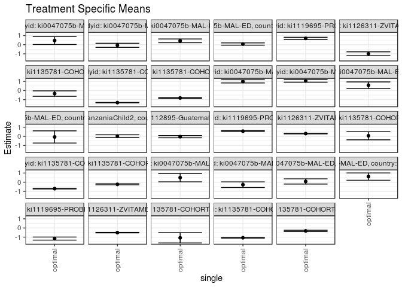

## Results Table

### Parameter: TSM

| agecat | studyid | country | intervention_level | baseline_level | estimate | ci_lower | ci_upper |
| --- | --- | --- | --- | --- | --- | --- | --- |
| Birth | ki0047075b-MAL-ED | BRAZIL | optimal | observed | 0.4947994 | 0.0360559 | 0.9535430 |
| Birth | ki0047075b-MAL-ED | PERU | optimal | observed | -0.2749824 | -0.5823844 | 0.0324196 |
| Birth | ki0047075b-MAL-ED | SOUTH AFRICA | optimal | observed | 0.0786792 | -0.2071150 | 0.3644735 |
| Birth | ki0047075b-MAL-ED | TANZANIA, UNITED REPUBLIC OF | optimal | observed | 0.6093884 | 0.2118388 | 1.0069380 |
| Birth | ki1119695-PROBIT | BELARUS | optimal | observed | -1.1589774 | -1.3271574 | -0.9907973 |
| Birth | ki1126311-ZVITAMBO | ZIMBABWE | optimal | observed | -0.5097879 | -0.5366148 | -0.4829610 |
| Birth | ki1135781-COHORTS | GUATEMALA | optimal | observed | -1.0737696 | -1.6359569 | -0.5115822 |
| Birth | ki1135781-COHORTS | INDIA | optimal | observed | -1.0676925 | -1.1081026 | -1.0272824 |
| Birth | ki1135781-COHORTS | PHILIPPINES | optimal | observed | -0.3189294 | -0.3907682 | -0.2470905 |
| 6 months | ki0047075b-MAL-ED | BRAZIL | optimal | observed | 1.0034115 | 0.8281581 | 1.1786649 |
| 6 months | ki0047075b-MAL-ED | PERU | optimal | observed | 1.0542569 | 0.9112575 | 1.1972563 |
| 6 months | ki0047075b-MAL-ED | SOUTH AFRICA | optimal | observed | 0.5836324 | 0.2252769 | 0.9419878 |
| 6 months | ki0047075b-MAL-ED | TANZANIA, UNITED REPUBLIC OF | optimal | observed | -0.0658058 | -0.7335469 | 0.6019353 |
| 6 months | ki1066203-TanzaniaChild2 | TANZANIA, UNITED REPUBLIC OF | optimal | observed | 0.0204375 | -0.1284927 | 0.1693676 |
| 6 months | ki1112895-Guatemala BSC | GUATEMALA | optimal | observed | -0.0349732 | -0.1562743 | 0.0863280 |
| 6 months | ki1119695-PROBIT | BELARUS | optimal | observed | 0.5647678 | 0.5045027 | 0.6250329 |
| 6 months | ki1126311-ZVITAMBO | ZIMBABWE | optimal | observed | 0.3023533 | 0.2715681 | 0.3331385 |
| 6 months | ki1135781-COHORTS | GUATEMALA | optimal | observed | 0.0642071 | -0.3782078 | 0.5066220 |
| 6 months | ki1135781-COHORTS | INDIA | optimal | observed | -0.7098964 | -0.7430301 | -0.6767627 |
| 6 months | ki1135781-COHORTS | PHILIPPINES | optimal | observed | -0.2375811 | -0.2914796 | -0.1836825 |
| 24 months | ki0047075b-MAL-ED | BRAZIL | optimal | observed | 0.4565349 | 0.0227881 | 0.8902818 |
| 24 months | ki0047075b-MAL-ED | PERU | optimal | observed | -0.0658299 | -0.2898223 | 0.1581626 |
| 24 months | ki0047075b-MAL-ED | SOUTH AFRICA | optimal | observed | 0.4229492 | 0.2167131 | 0.6291853 |
| 24 months | ki0047075b-MAL-ED | TANZANIA, UNITED REPUBLIC OF | optimal | observed | 0.0709279 | -0.0537010 | 0.1955567 |
| 24 months | ki1119695-PROBIT | BELARUS | optimal | observed | 0.6909792 | 0.5731833 | 0.8087751 |
| 24 months | ki1126311-ZVITAMBO | ZIMBABWE | optimal | observed | -0.9916125 | -1.2042173 | -0.7790076 |
| 24 months | ki1135781-COHORTS | GUATEMALA | optimal | observed | -0.3362773 | -0.6360297 | -0.0365249 |
| 24 months | ki1135781-COHORTS | INDIA | optimal | observed | -1.3240587 | -1.3462915 | -1.3018258 |
| 24 months | ki1135781-COHORTS | PHILIPPINES | optimal | observed | -0.8144530 | -0.8499528 | -0.7789532 |

### Parameter: E(Y)

| agecat | studyid | country | intervention_level | baseline_level | estimate | ci_lower | ci_upper |
| --- | --- | --- | --- | --- | --- | --- | --- |
| Birth | ki0047075b-MAL-ED | BRAZIL | observed | observed | 0.4038798 | 0.2296279 | 0.5781316 |
| Birth | ki0047075b-MAL-ED | PERU | observed | observed | -0.0735842 | -0.1836203 | 0.0364518 |
| Birth | ki0047075b-MAL-ED | SOUTH AFRICA | observed | observed | -0.0562791 | -0.2000837 | 0.0875255 |
| Birth | ki0047075b-MAL-ED | TANZANIA, UNITED REPUBLIC OF | observed | observed | 0.7932203 | 0.5962220 | 0.9902187 |
| Birth | ki1119695-PROBIT | BELARUS | observed | observed | -1.1463469 | -1.3562674 | -0.9364264 |
| Birth | ki1126311-ZVITAMBO | ZIMBABWE | observed | observed | -0.5145122 | -0.5404077 | -0.4886167 |
| Birth | ki1135781-COHORTS | GUATEMALA | observed | observed | -1.0552243 | -1.1617873 | -0.9486614 |
| Birth | ki1135781-COHORTS | INDIA | observed | observed | -0.9765068 | -1.0113301 | -0.9416835 |
| Birth | ki1135781-COHORTS | PHILIPPINES | observed | observed | -0.7377902 | -0.7844819 | -0.6910986 |
| 6 months | ki0047075b-MAL-ED | BRAZIL | observed | observed | 0.9717225 | 0.8073791 | 1.1360658 |
| 6 months | ki0047075b-MAL-ED | PERU | observed | observed | 1.0543956 | 0.9326967 | 1.1760945 |
| 6 months | ki0047075b-MAL-ED | SOUTH AFRICA | observed | observed | 0.5420735 | 0.3899459 | 0.6942011 |
| 6 months | ki0047075b-MAL-ED | TANZANIA, UNITED REPUBLIC OF | observed | observed | 0.5170513 | 0.3872178 | 0.6468847 |
| 6 months | ki1066203-TanzaniaChild2 | TANZANIA, UNITED REPUBLIC OF | observed | observed | 0.0797577 | 0.0268998 | 0.1326156 |
| 6 months | ki1112895-Guatemala BSC | GUATEMALA | observed | observed | -0.0568833 | -0.1722874 | 0.0585208 |
| 6 months | ki1119695-PROBIT | BELARUS | observed | observed | 0.5789633 | 0.5190130 | 0.6389137 |
| 6 months | ki1126311-ZVITAMBO | ZIMBABWE | observed | observed | 0.3050103 | 0.2788985 | 0.3311222 |
| 6 months | ki1135781-COHORTS | GUATEMALA | observed | observed | 0.1920134 | 0.1173734 | 0.2666534 |
| 6 months | ki1135781-COHORTS | INDIA | observed | observed | -0.7104795 | -0.7428008 | -0.6781581 |
| 6 months | ki1135781-COHORTS | PHILIPPINES | observed | observed | -0.2936948 | -0.3352840 | -0.2521057 |
| 24 months | ki0047075b-MAL-ED | BRAZIL | observed | observed | 0.4466272 | 0.2416144 | 0.6516401 |
| 24 months | ki0047075b-MAL-ED | PERU | observed | observed | 0.1199005 | -0.0000331 | 0.2398341 |
| 24 months | ki0047075b-MAL-ED | SOUTH AFRICA | observed | observed | 0.4267017 | 0.3074751 | 0.5459283 |
| 24 months | ki0047075b-MAL-ED | TANZANIA, UNITED REPUBLIC OF | observed | observed | 0.0500935 | -0.0748234 | 0.1750103 |
| 24 months | ki1119695-PROBIT | BELARUS | observed | observed | 0.6863435 | 0.5745700 | 0.7981170 |
| 24 months | ki1126311-ZVITAMBO | ZIMBABWE | observed | observed | -1.1781043 | -1.2781256 | -1.0780830 |
| 24 months | ki1135781-COHORTS | GUATEMALA | observed | observed | -0.2796964 | -0.3351582 | -0.2242346 |
| 24 months | ki1135781-COHORTS | INDIA | observed | observed | -0.6594122 | -0.6925753 | -0.6262491 |
| 24 months | ki1135781-COHORTS | PHILIPPINES | observed | observed | -0.6100579 | -0.6471813 | -0.5729344 |

### Parameter: PAR

| agecat | studyid | country | intervention_level | baseline_level | estimate | ci_lower | ci_upper |
| --- | --- | --- | --- | --- | --- | --- | --- |
| Birth | ki0047075b-MAL-ED | BRAZIL | optimal | observed | -0.0909196 | -0.5266671 | 0.3448278 |
| Birth | ki0047075b-MAL-ED | PERU | optimal | observed | 0.2013982 | -0.0757463 | 0.4785426 |
| Birth | ki0047075b-MAL-ED | SOUTH AFRICA | optimal | observed | -0.1349583 | -0.3702564 | 0.1003397 |
| Birth | ki0047075b-MAL-ED | TANZANIA, UNITED REPUBLIC OF | optimal | observed | 0.1838320 | -0.2380720 | 0.6057359 |
| Birth | ki1119695-PROBIT | BELARUS | optimal | observed | 0.0126304 | -0.1015982 | 0.1268591 |
| Birth | ki1126311-ZVITAMBO | ZIMBABWE | optimal | observed | -0.0047243 | -0.0118793 | 0.0024308 |
| Birth | ki1135781-COHORTS | GUATEMALA | optimal | observed | 0.0185452 | -0.5331690 | 0.5702595 |
| Birth | ki1135781-COHORTS | INDIA | optimal | observed | 0.0911856 | 0.0590083 | 0.1233630 |
| Birth | ki1135781-COHORTS | PHILIPPINES | optimal | observed | -0.4188608 | -0.4814415 | -0.3562802 |
| 6 months | ki0047075b-MAL-ED | BRAZIL | optimal | observed | -0.0316890 | -0.1042608 | 0.0408827 |
| 6 months | ki0047075b-MAL-ED | PERU | optimal | observed | 0.0001387 | -0.1120154 | 0.1122928 |
| 6 months | ki0047075b-MAL-ED | SOUTH AFRICA | optimal | observed | -0.0415589 | -0.3433449 | 0.2602271 |
| 6 months | ki0047075b-MAL-ED | TANZANIA, UNITED REPUBLIC OF | optimal | observed | 0.5828570 | -0.0749210 | 1.2406351 |
| 6 months | ki1066203-TanzaniaChild2 | TANZANIA, UNITED REPUBLIC OF | optimal | observed | 0.0593202 | -0.0768797 | 0.1955202 |
| 6 months | ki1112895-Guatemala BSC | GUATEMALA | optimal | observed | -0.0219101 | -0.0633154 | 0.0194952 |
| 6 months | ki1119695-PROBIT | BELARUS | optimal | observed | 0.0141955 | -0.0025619 | 0.0309529 |
| 6 months | ki1126311-ZVITAMBO | ZIMBABWE | optimal | observed | 0.0026570 | -0.0143811 | 0.0196951 |
| 6 months | ki1135781-COHORTS | GUATEMALA | optimal | observed | 0.1278063 | -0.3031676 | 0.5587803 |
| 6 months | ki1135781-COHORTS | INDIA | optimal | observed | -0.0005831 | -0.0018978 | 0.0007317 |
| 6 months | ki1135781-COHORTS | PHILIPPINES | optimal | observed | -0.0561138 | -0.0921491 | -0.0200784 |
| 24 months | ki0047075b-MAL-ED | BRAZIL | optimal | observed | -0.0099077 | -0.4200189 | 0.4002034 |
| 24 months | ki0047075b-MAL-ED | PERU | optimal | observed | 0.1857304 | -0.0046890 | 0.3761498 |
| 24 months | ki0047075b-MAL-ED | SOUTH AFRICA | optimal | observed | 0.0037525 | -0.1714297 | 0.1789347 |
| 24 months | ki0047075b-MAL-ED | TANZANIA, UNITED REPUBLIC OF | optimal | observed | -0.0208344 | -0.0516224 | 0.0099536 |
| 24 months | ki1119695-PROBIT | BELARUS | optimal | observed | -0.0046357 | -0.0192747 | 0.0100033 |
| 24 months | ki1126311-ZVITAMBO | ZIMBABWE | optimal | observed | -0.1864918 | -0.4015190 | 0.0285355 |
| 24 months | ki1135781-COHORTS | GUATEMALA | optimal | observed | 0.0565809 | -0.2309749 | 0.3441368 |
| 24 months | ki1135781-COHORTS | INDIA | optimal | observed | 0.6646464 | 0.6307044 | 0.6985884 |
| 24 months | ki1135781-COHORTS | PHILIPPINES | optimal | observed | 0.2043952 | 0.1746358 | 0.2341545 |